# Path vs tracker log analysis

## Analysis

### Read logs

```python
import csv

def import_csv_to_dictionary(csv_file):
    dictionary = {}
    with open(csv_file) as file:
        reader = csv.reader(file)
        headers = [header.strip() for header in next(reader)[1:]]
        for header in headers:
            dictionary[header] = []
        for row in file:
            values = [float(value.strip()) for value in row.split(",")[1:]]
            for i in range(len(values)):
                dictionary[headers[i]].append(values[i])
    return dictionary

path = import_csv_to_dictionary('logs/path.csv')
print("Path Headers: " + str(path.keys()))
tracker = import_csv_to_dictionary('logs/tracker.csv')
print("Tracker Headers: " + str(tracker.keys()))
```

```
Path Headers: dict_keys(['index', 'x_pth', 'y_pth', 'z_pth', 't_pth'])
Tracker Headers: dict_keys(['index', 'x_trk', 'y_trk', 'z_trk', 't_trk'])
```

### Initial plots

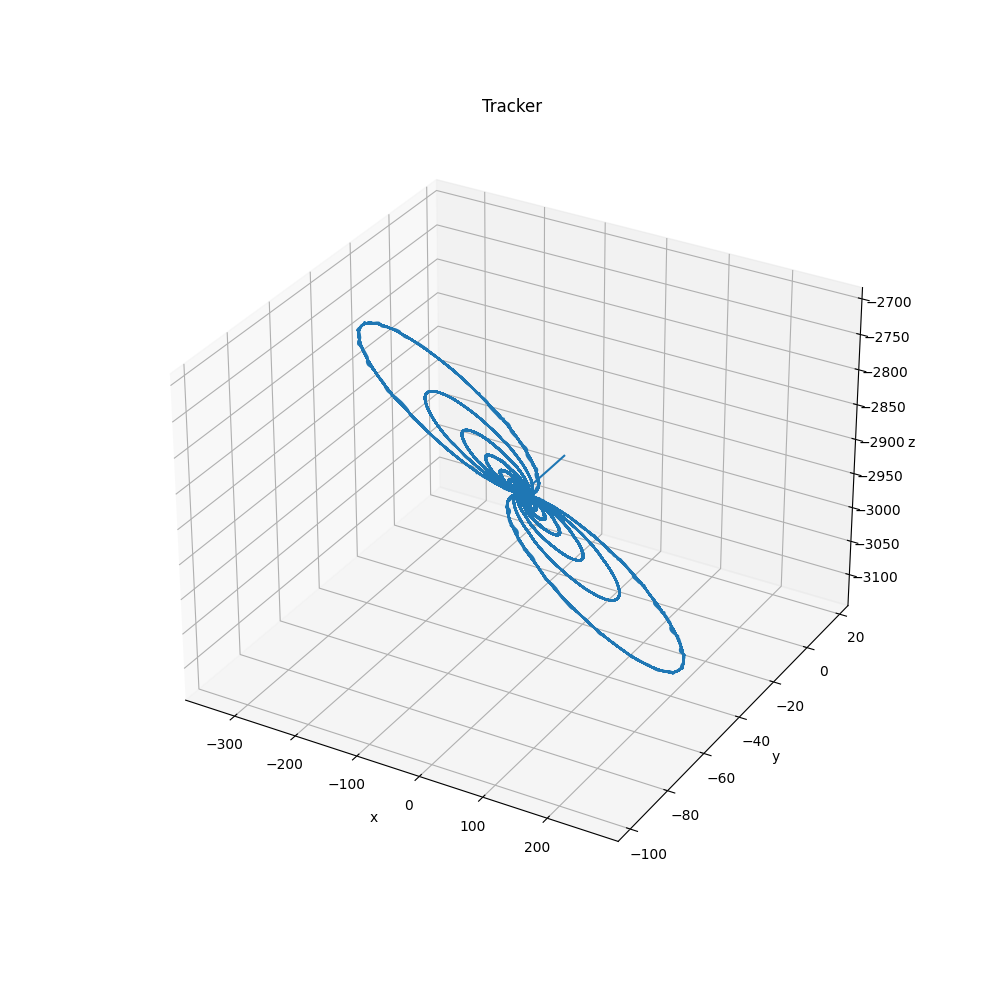

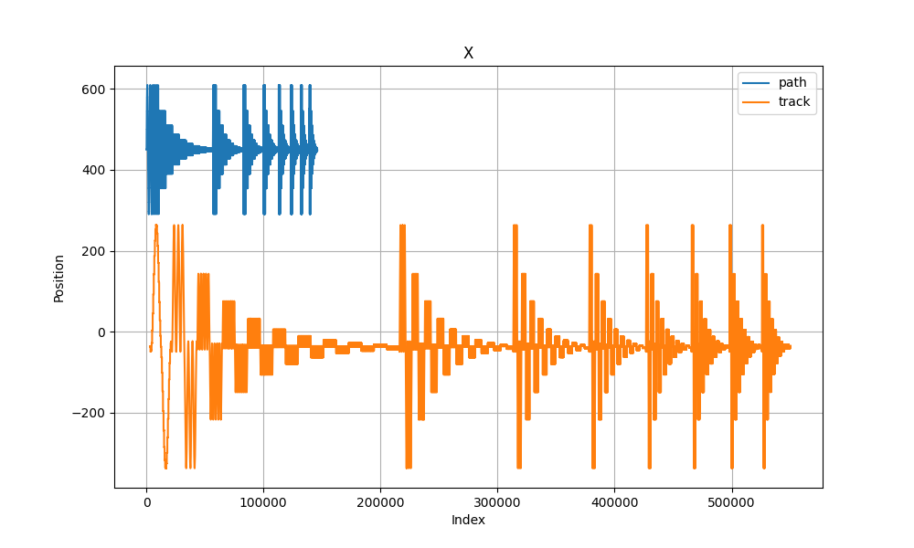

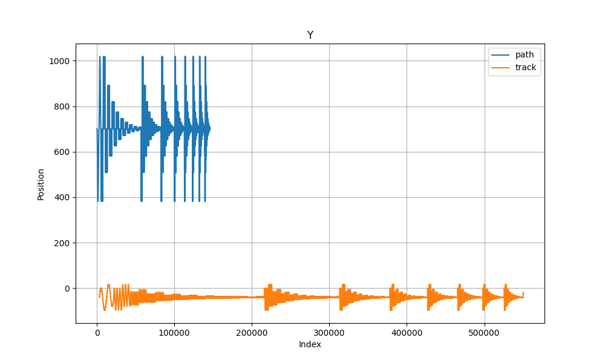

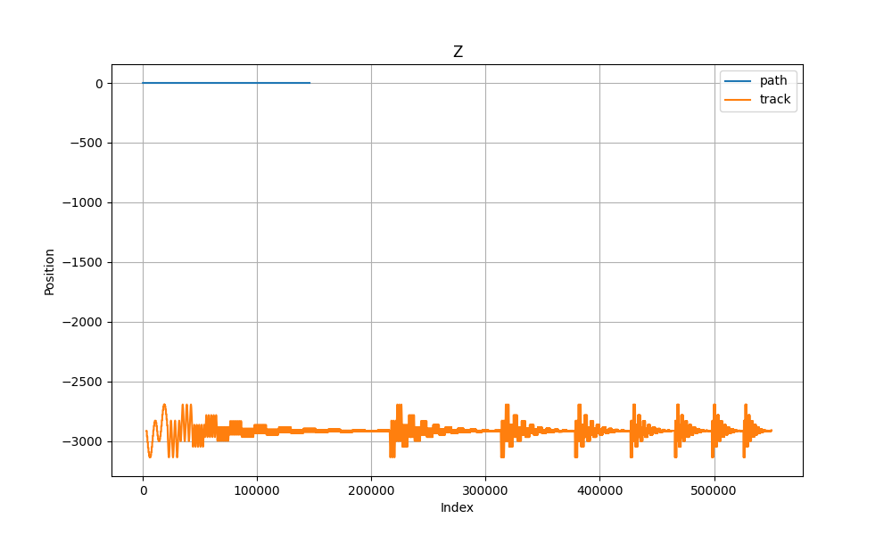

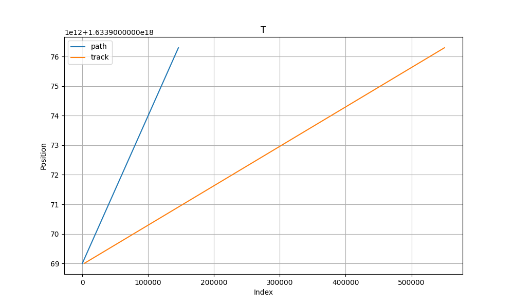

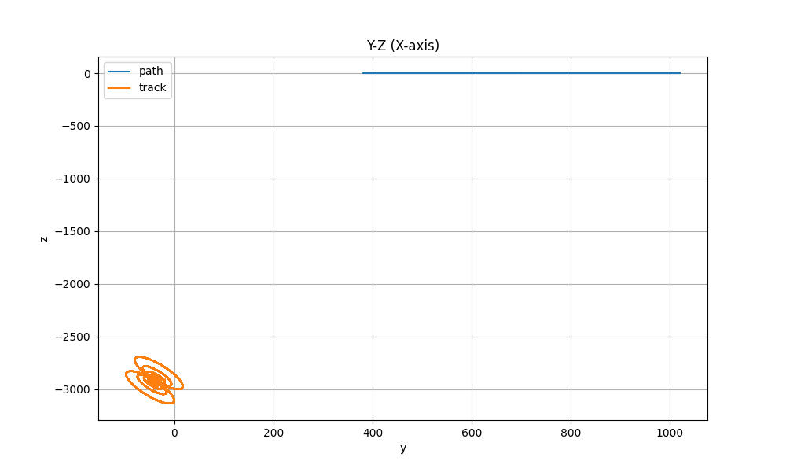

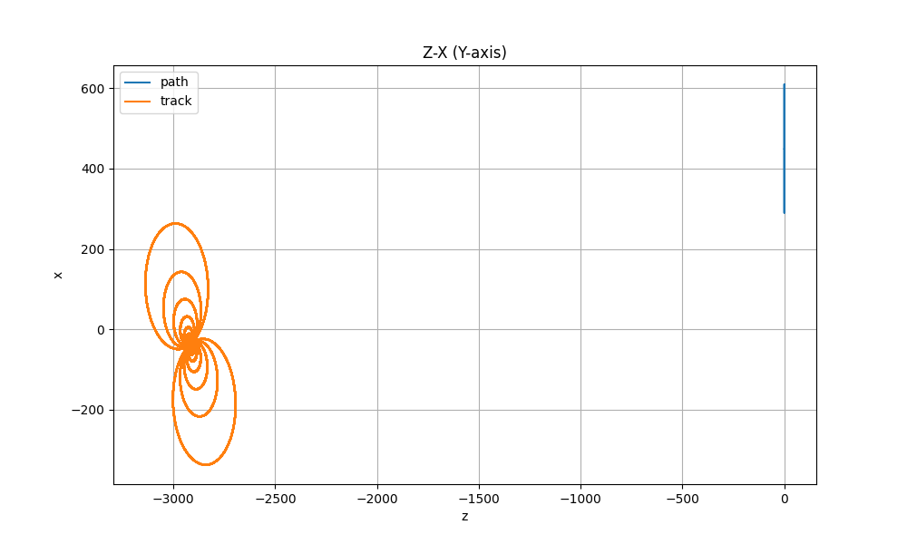

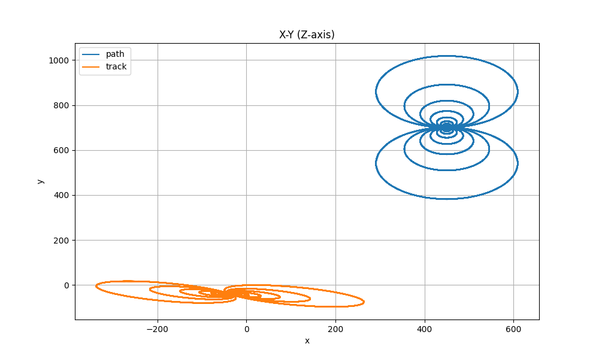

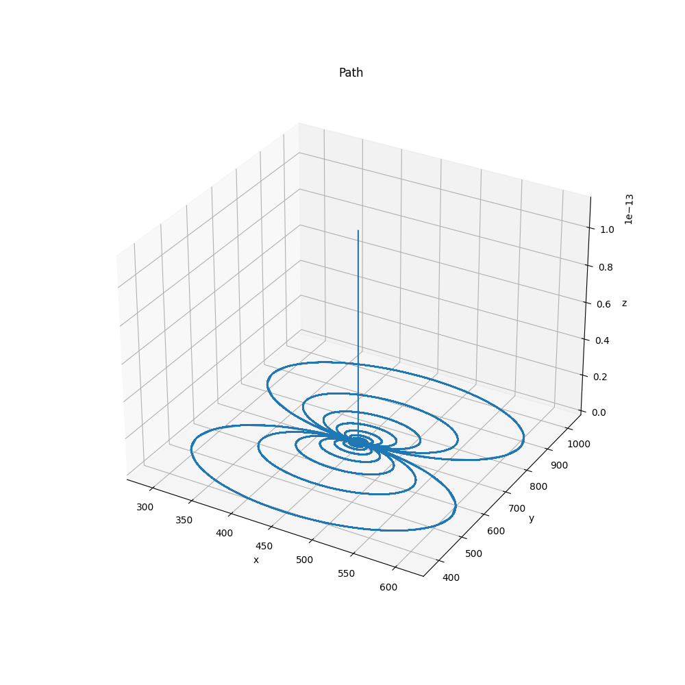

```python
# Enabling the `widget` backend.
# This requires jupyter-matplotlib a.k.a. ipympl.
%matplotlib widget
from mpl_toolkits.mplot3d import Axes3D
from matplotlib import pyplot as plot

def comparison_plot(x1, y1, x2, y2, title, xlabel='Index' ,ylabel='Position', range=None):
    figure, plt = plot.subplots()
    figure.set_size_inches(10, 6)
    plt.plot(x1, y1, x2, y2)
    plt.grid()
    if range:
        plt.set_xlim(range)
    plt.legend(['path', 'track'])
    plt.set_xlabel(xlabel)
    plt.set_ylabel(ylabel)
    plt.set_title(title)
    return figure, plt

def all_axis_plot(x, y, z, title):
    figure = plot.figure()
    figure.set_size_inches(10, 10)
    plt = plot.axes(projection='3d')
    plt.plot(x, y, z)
    plt.grid()
    plt.set_xlabel('x')
    plt.set_ylabel('y')
    plt.set_zlabel('z')
    plt.set_title(title)
    return figure, plt

comparison_plot(path['index'], path['x_pth'], tracker['index'], tracker['x_trk'], 'X')
comparison_plot(path['index'], path['y_pth'], tracker['index'], tracker['y_trk'], 'Y')
comparison_plot(path['index'], path['z_pth'], tracker['index'], tracker['z_trk'], 'Z')
comparison_plot(path['index'], path['t_pth'], tracker['index'], tracker['t_trk'], 'T')

comparison_plot(path['y_pth'], path['z_pth'], tracker['y_trk'], tracker['z_trk'], 'Y-Z (X-axis)', 'y', 'z')
comparison_plot(path['z_pth'], path['x_pth'], tracker['z_trk'], tracker['x_trk'], 'Z-X (Y-axis)', 'z', 'x')
comparison_plot(path['x_pth'], path['y_pth'], tracker['x_trk'], tracker['y_trk'], 'X-Y (Z-axis)', 'x', 'y')

all_axis_plot(path['x_pth'], path['y_pth'], path['z_pth'], 'Path')
all_axis_plot(tracker['x_trk'], tracker['y_trk'], tracker['z_trk'], 'Tracker')

plot.show()
```


### Perform `tracker` reference frame rotations

```
X Rotation: 104.49332965534326
Y Rotation: 42.84817710547796
Z Rotation: 166.51664398072393
```

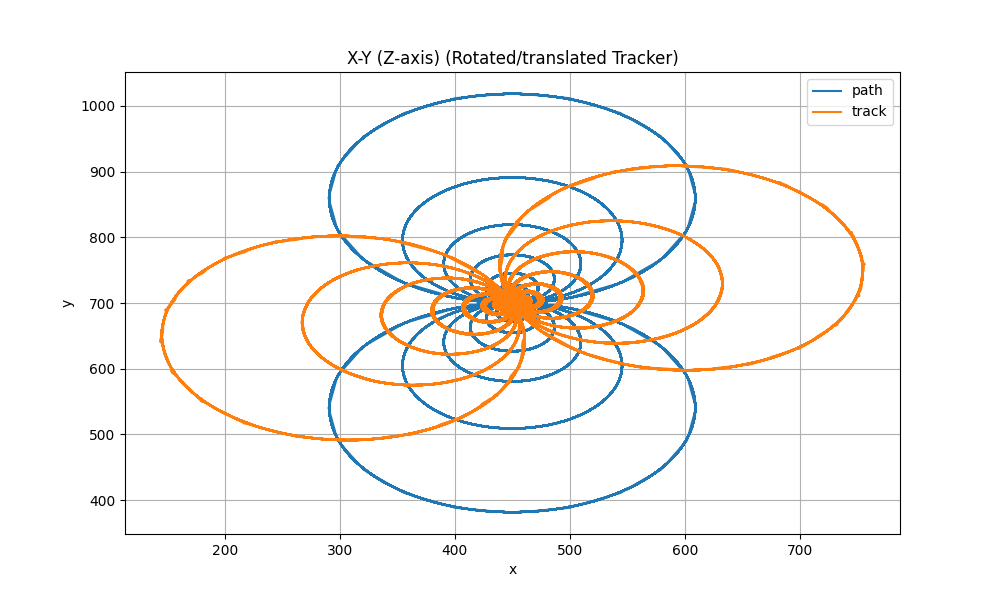

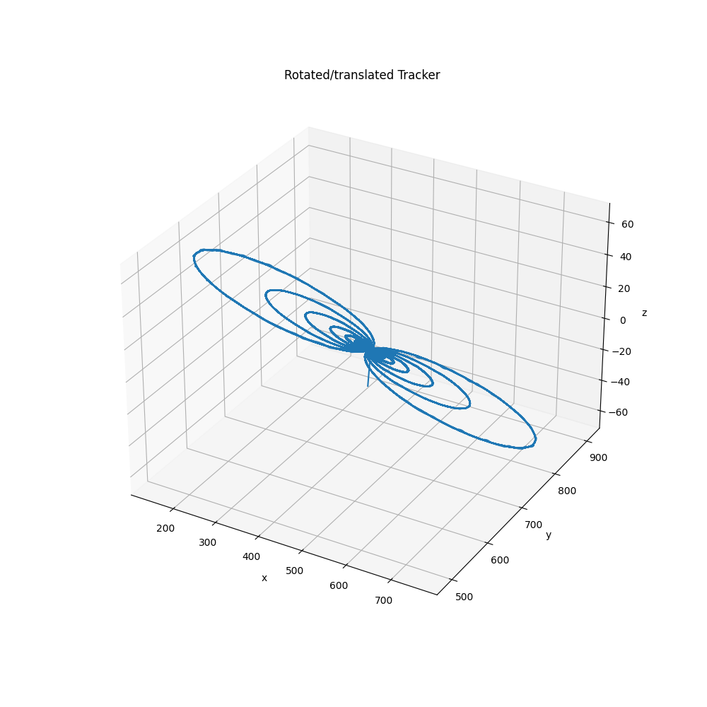

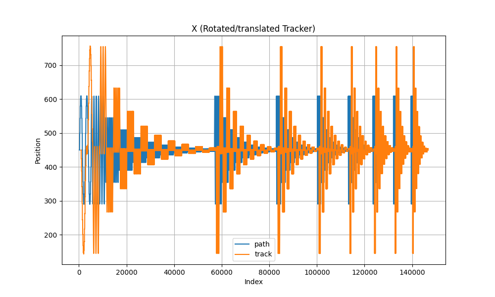

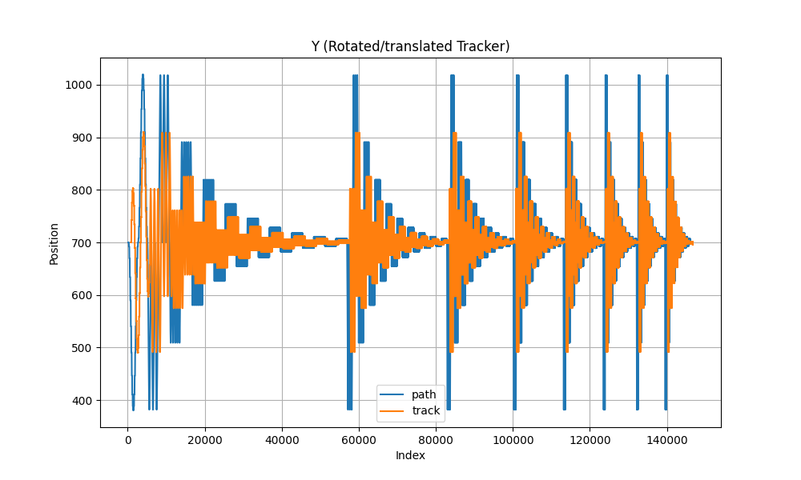

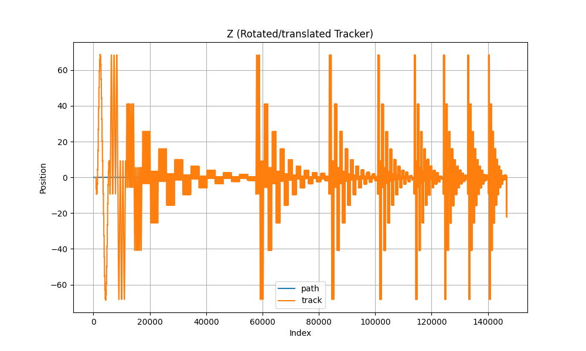

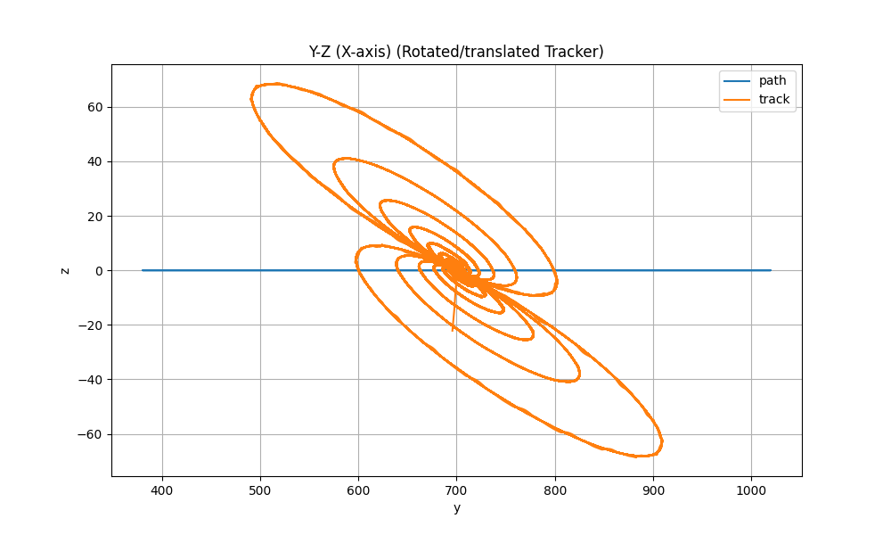

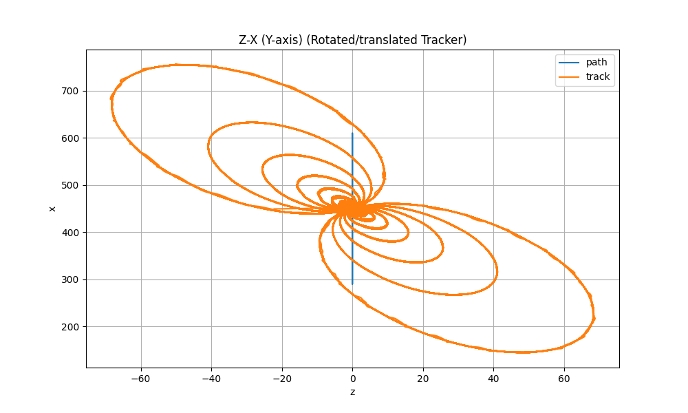

```python
import numpy as np
import math

def plane_from_3_points(point1, point2, point3):
    # each point is an array with x, y, z coordinates
    p1 = np.array(point1)
    p2 = np.array(point2)
    p3 = np.array(point3)
    v1 = p3 - p1
    v2 = p2 - p1
    cp = np.cross(v1, v2)
    a, b, c = cp
    d = np.dot(cp, p1)
    # return equation of plane in form a * x + b * y + c * z + d = 0 so [a,b,c,d]
    return [a, b, c, -d]

def planes_intersection(plane1, plane2):
    # each plane is an described by normal vector [a, b, c, d]
    a_vec, b_vec = np.array(plane1[:3]), np.array(plane2[:3])
    aXb_vec = np.cross(a_vec, b_vec)
    m = np.array((a_vec, b_vec, aXb_vec))
    x = np.array((-plane1[3], -plane2[3], 0.0))
    intersection_point = np.linalg.solve(m, x)
    # returns a vector [x, y, z] and point at the intersection [x,y,z]
    return aXb_vec, intersection_point

def angle_between_two_vectors(vector1, vector2):
    dot_product = np.dot(vector1, vector2)
    magnitude = np.linalg.norm(vector1) * np.linalg.norm(vector2)
    angle = np.arccos(dot_product/magnitude)
    # Returns angle in radians
    return(angle)

def rotation_matrix(x_angle, y_angle, z_angle):
    # angles must be provided in radians
    def x_rotation_matrix(theta):
        return np.matrix([[1, 0 , 0],[0, math.cos(theta), -math.sin(theta)],[0, math.sin(theta), math.cos(theta)]])
    def y_rotation_matrix(theta):
        return np.matrix([[math.cos(theta), 0, math.sin(theta)], [0, 1, 0], [-math.sin(theta), 0, math.cos(theta)]])
    def z_rotation_matrix(theta):
        return np.matrix([[math.cos(theta), -math.sin(theta), 0], [math.sin(theta), math.cos(theta) , 0], [0, 0 , 1]])
    return x_rotation_matrix(x_angle) * y_rotation_matrix(y_angle) * z_rotation_matrix(z_angle)

def rotate_points_to_xy_plane(data, x_key, y_key, z_key, p1_index, p2_index, p3_index, origin = [0,0,0]):
    p1 = [data[x_key][p1_index], data[y_key][p1_index], data[z_key][p1_index]]
    p2 = [data[x_key][p2_index], data[y_key][p2_index], data[z_key][p2_index]]
    p3 = [data[x_key][p3_index], data[y_key][p3_index], data[z_key][p3_index]]

    # plane defintions in the form of [a, b, c, d] where a * x + b * y + c * z = d
    yz_plane = [1, 0, 0, 0]
    x_vector = yz_plane[:3]
    xz_plane = [0, 1, 0, 0]
    y_vector = xz_plane[:3]
    xy_plane = [0, 0, 1, 0]
    z_vector = xy_plane[:3]
    plane = plane_from_3_points(p1, p2, p3)
    yz_vector, yz_point = planes_intersection(plane, yz_plane)
    xz_vector, xz_point = planes_intersection(plane, xz_plane)
    xy_vector, xy_point = planes_intersection(plane, xy_plane)

    x_rotation = angle_between_two_vectors(yz_vector, y_vector)
    y_rotation = angle_between_two_vectors(xz_vector, x_vector)
    z_rotation = angle_between_two_vectors(xy_vector, x_vector)

    print('X Rotation: ' + str(np.degrees(x_rotation)))
    print('Y Rotation: ' + str(np.degrees(y_rotation)))
    print('Z Rotation: ' + str(np.degrees(z_rotation)))

    x = []
    y = []
    z = []
    x_mean = np.mean(data[x_key])
    y_mean = np.mean(data[y_key])
    z_mean = np.mean(data[z_key])
    rotation = rotation_matrix(x_rotation, y_rotation, z_rotation)
    for i in range(len(data[x_key])):
        point = np.matrix([[data[x_key][i] - x_mean], [data[y_key][i] - y_mean], [data[z_key][i] - z_mean]])
        point = rotation * point
        x.append(point[0, 0] + origin[0])
        y.append(point[1, 0] + origin[1])
        z.append(point[2, 0] + origin[2])
    return x, y, z

def plot_plane(plt, plane):
    x, y = np.meshgrid(np.linspace(-100, 100, 2), np.linspace(-100, 100, 2))
    z = (-plane[0] * x + -plane[1] * y + -plane[3])/plane[2]
    plt.plot_surface(x, y, z)
    return plt

def plot_vector(plt, vector, origin = [0,0,0], length = 500):
    plt.quiver(origin[0], origin[1], origin[0], vector[0], vector[1], vector[2], length = length, normalize=True)
    return plt

# Scale `tracker` index
tracker['index'] = np.array(tracker['index'])*(len(path['index'])/len(tracker['index']))

# Perform rotation/translation
origin = [np.mean(path['x_pth']), np.mean(path['y_pth']), np.mean(path['z_pth'])]
tracker['xr'], tracker['yr'], tracker['zr'] = rotate_points_to_xy_plane(tracker, 'x_trk', 'y_trk', 'z_trk', 300000, 400000, 500000, origin)

all_axis_plot(tracker['xr'], tracker['yr'], tracker['zr'], 'Rotated/translated Tracker')

comparison_plot(path['index'], path['x_pth'], tracker['index'], tracker['xr'], 'X (Rotated/translated Tracker)')
comparison_plot(path['index'], path['y_pth'], tracker['index'], tracker['yr'], 'Y (Rotated/translated Tracker)')
comparison_plot(path['index'], path['z_pth'], tracker['index'], tracker['zr'], 'Z (Rotated/translated Tracker)')

comparison_plot(path['y_pth'], path['z_pth'], tracker['yr'], tracker['zr'], 'Y-Z (X-axis) (Rotated/translated Tracker)', 'y', 'z')
comparison_plot(path['z_pth'], path['x_pth'], tracker['zr'], tracker['xr'], 'Z-X (Y-axis) (Rotated/translated Tracker)', 'z', 'x')
comparison_plot(path['x_pth'], path['y_pth'], tracker['xr'], tracker['yr'], 'X-Y (Z-axis) (Rotated/translated Tracker)', 'x', 'y')

plot.show()
```

## Wrap up notes

- Unfortunatley I was unable to properly perform rotation of `tracker` to properly compare those points to `path` in the time I allocated to this task.
- Attempted strategy
  - Match plane to `tracker` data set by picking 3 points to form two vectors which are used to find the normal vector of the plane.
  - Intersect the `tracker` plane with the XY, XZ, and YZ planes to get vectors in the coordinat system.
  - Use those vectors and unit X, Y, Z vectors to calculate the X, Y, and Z angle of the `tracker` plane.
  - Use those anlges to calulate a rotation matrix of the desired rotation.
  - Transform and and rotate each point to match that of `path` which is on the XY plane.
    - This is where I am running into trouble. The rotation matrix looks correct as tested with various known planes but the rotation is not performing as expected. The planes end up skewed. There is more troubleshooting to be done in this section
- This is has been a fun exercise but I imagine in the real work place it would have likely been faster to contact the machine expert or company to get the correct transformation matrix as it should be known.

### Conclusion

- Although I was unable properly compare `path` to `tracker` the 3D plots show that `tracker` and `path` generally match in shape.
  - This leads me to beleive that the difference in coordinate systems might be part of the problem. Its possible the machine has logic in it to not move to points which are outside of its cabability as this could damage the machine.
- Does not appear to be a unit mismatch issue as the scale appears to match between `tracker` and `path`.

#### Next Steps

- Look at the last know path to run on this machine, does it have the same coordinate system offset?
- Mechanical troubleshooting is worth checking, are the steppers on each axis actually connected to power?
- Spend more time troubleshooting rotation matrix issues.